# Chapter 5 Nonlinear models

## Multivariate Adaptive Regression Splines (MARS)

**Multivariate Adaptive Regression Splines (MARS)** is a powerful and flexible modeling technique widely used in **modern data mining, machine learning, and predictive analytics**, capable of handling both **regression** and **classification** problems. It extends traditional linear models by relaxing the assumption of a fixed, global functional form between the response variable and predictor variables. Instead, MARS operates as a **nonparametric regression method**, allowing the data itself to determine the model structure.

Unlike standard linear regression, which fits a single global equation, MARS constructs **piecewise linear regression models** over different regions of the predictor space. These regions are defined by **knots** (also called **cutpoints**), which divide the data into intervals where separate linear relationships are fitted. This adaptive process enables MARS to **capture nonlinear patterns, variable interactions, and local behaviors** that are often missed by traditional models.

The modeling engine of MARS identifies important **basis functions**—pairs of piecewise linear terms representing the effects of predictors above or below each knot. Through an iterative forward and backward stepwise procedure, it builds a model that balances goodness-of-fit and parsimony, often guided by the **Generalized Cross-Validation (GCV)** criterion. As a result, MARS achieves a good compromise between interpretability and flexibility, offering regression results similar to polynomial or spline models but with greater automation and robustness.

In essence, MARS provides a **data-driven, interpretable approach** to modeling complex relationships, effectively uncovering hidden patterns and significant variable effects in high-dimensional datasets.

The general form of a MARS model is:

$$ \hat{y} = \beta_0 + \sum_{m=1}^{M} \beta_m B_m(x) $$

where:

- $\hat{y}$ is the predicted response,
- $\beta_0$ is the intercept term,
- $\beta_m$ are coefficients estimated from the data,
- $B_m(x)$ are **basis functions** derived from the predictor variables.

Each **basis function** $B_m(x)$ takes the form of a **hinge function** (or piecewise linear spline):

$$ h(x, t) = \max(0, x - t) \quad \text{or} \quad \max(0, t - x) $$

where $t$ represents a **knot** or cutpoint. These hinge functions allow the model to flexibly change slopes at various points in the data, capturing nonlinearities. MARS can also model **interactions** between variables by multiplying two or more hinge functions, such as:

$$ B(x) = h(x_1, t_1) \times h(x_2, t_2) $$

The MARS procedure begins by identifying a point across the range of $X$ values where two different linear relationships between $Y$ and $X$ achieve the smallest overall error.  
The resulting split is represented by a **hinge function**, denoted as $h(x - a)$, where $a$ is the **cutpoint** or **knot** value.

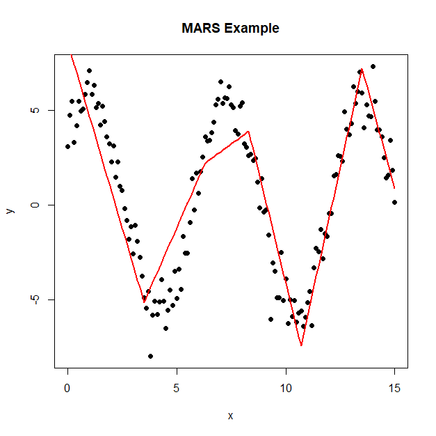

For example, the hinge function can be expressed as:

$$ h(x, x_0) = \max(0, x - x_0) $$

When the cutpoint occurs at $x_0 = 1.3$, the hinge function becomes:

$$ h(x - 1.3) = \begin{cases} 0, & x < 1.3 \\ x - 1.3, & x \ge 1.3 \end{cases} $$

This hinge function allows two separate linear relationships to be modeled on either side of the cutpoint:

$$ y = \begin{cases} \beta_{01} + \beta_{11} (1.3 - x), & \text{if } x < 1.3 \\ \beta_{02} + \beta_{12} (x - 1.3), & \text{if } x \ge 1.3 \end{cases} $$

This formulation effectively captures a **localized change in slope** at the knot $x = 1.3$, allowing the MARS model to adapt to structural changes in the data without imposing a global nonlinear form.

The MARS algorithm builds its model in two main phases:

1. **Forward Step:**  
   Sequentially adds pairs of basis functions to minimize residual error and improve model fit.
2. **Backward Step (Pruning):**  
   Removes redundant or insignificant terms using the **Generalized Cross-Validation (GCV)** criterion to control model complexity.

R pakcage "earth"

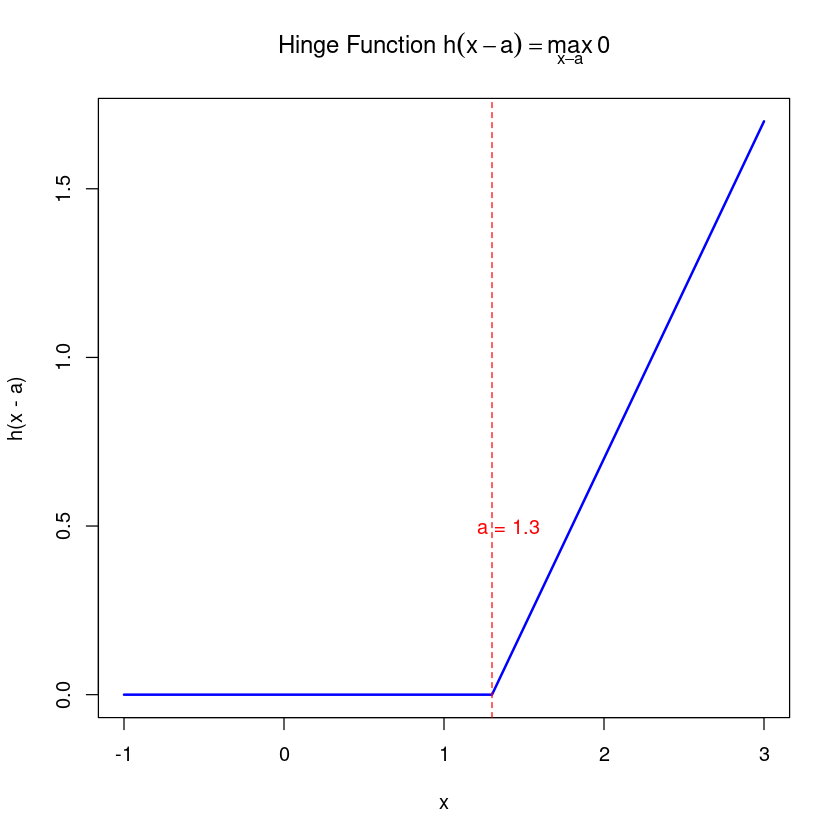

```r
# Define hinge function
hinge = function(x, a) {
  pmax(0, x - a)
}

# Set parameters
a = 1.3
x = seq(-1, 3, by = 0.1)
y = hinge(x, a)

# Plot the hinge function
plot(x, y, type = "l", lwd = 2, col = "blue",
     main = expression(paste("Hinge Function ", h(x - a) == max(0, x - a))),
     xlab = "x", ylab = "h(x - a)")
abline(v = a, col = "red", lty = 2)  # indicate the knot
text(a + 0.1, 0.5, paste("a =", a), col = "red")
```

```r
#MARS
library(earth)
```

Example: Simulates a nonlinear relationship, fits a MARS model using the earth package, and visualizes the predictions.

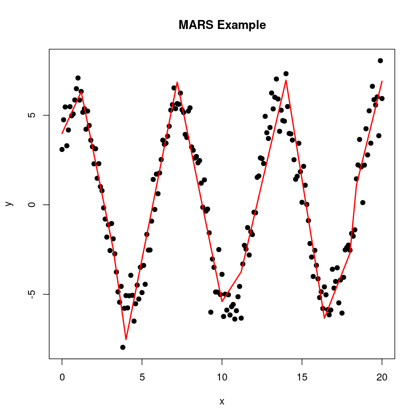

```r
#Simulate some example data
set.seed(372)
x = seq(0, 20, by = 0.1)
y = 5 * sin(x) + 3*cos(x) + rnorm(length(x))

#Create a data frame
dat = data.frame(x = x, y = y)

#Fit a MARS model
mars_fit = earth(y ~ x, data = dat)

#Summary of the fit
#summary(mars_fit)

#Make predictions using the MARS model
new_data = data.frame(x = seq(0, 20, by = 0.1))
predictions = predict(mars_fit, newdata = new_data)

#Plot the original data and MARS predictions
plot(x, y, main = "MARS Example", xlab = "x", ylab = "y", pch = 19)
lines(new_data$x, predictions, col = "red", lwd = 2)
```

1.28051433736475

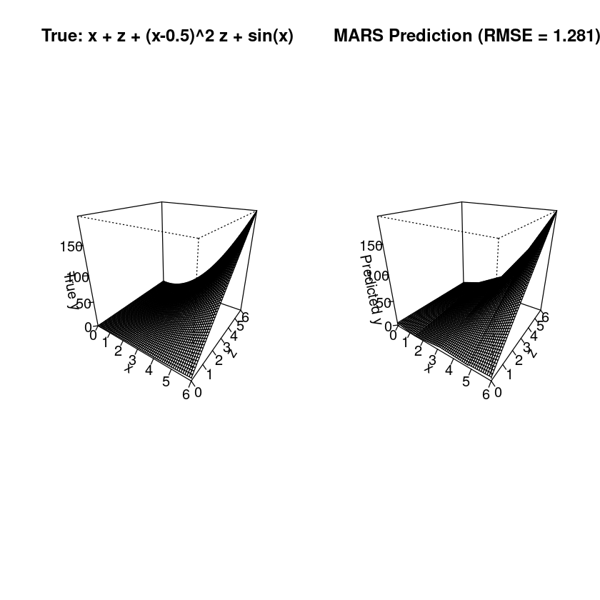

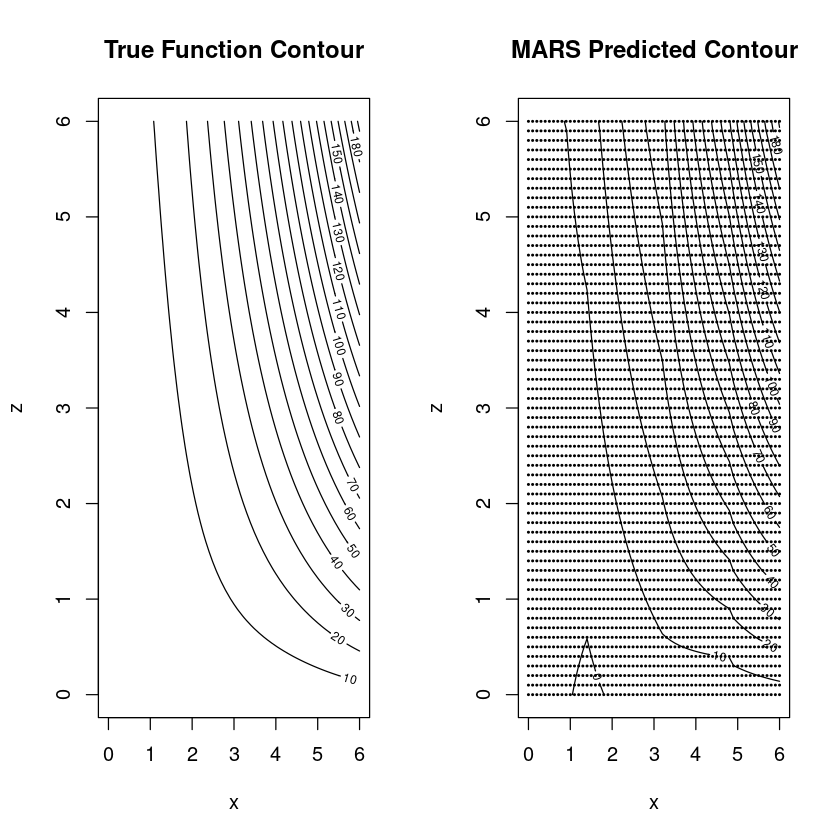

```r
# --- Simulate data: y = x + z + (x-0.5)^2 * z + sin(x) + noise ---
set.seed(372)

# Predictor sequences and grid
x_seq = seq(0, 6, by = 0.1)
z_seq = seq(0, 6, by = 0.1)
grid = expand.grid(x = x_seq, z = z_seq)

# True surface and noisy response
f_true = with(grid, x + z + (x - 0.5)^2 * z + sin(x))
y = f_true + rnorm(nrow(grid), sd = 0.3)

# Data frame for modeling
dat = data.frame(x = grid$x, z = grid$z, y = y)

# --- Fit MARS with interactions (degree = 2 allows x:z terms) ---
# install.packages("earth")  # if needed
library(earth)
mars_fit = earth(y ~ x + z, data = dat, degree = 2)

# --- Predictions on the same grid ---
pred_vec = predict(mars_fit, newdata = grid)

# Reshape to matrices for plotting
nx = length(x_seq); nz = length(z_seq)
true_mat = matrix(f_true, nrow = nx, ncol = nz, byrow = FALSE)
pred_mat = matrix(pred_vec, nrow = nx, ncol = nz, byrow = FALSE)

# RMSE against the true surface
rmse = sqrt(mean((pred_vec - f_true)^2))
rmse

# --- 3D surfaces: True vs Predicted ---
op = par(mfrow = c(1, 2))
persp(x_seq, z_seq, true_mat,
      theta = 35, phi = 25,
      xlab = "x", ylab = "z", zlab = "True y",
      main = "True: x + z + (x-0.5)^2 z + sin(x)",
      ticktype = "detailed")
persp(x_seq, z_seq, pred_mat,
      theta = 35, phi = 25,
      xlab = "x", ylab = "z", zlab = "Predicted y",
      main = paste0("MARS Prediction (RMSE = ", round(rmse, 3), ")"),
      ticktype = "detailed")

# --- Contour comparison with training points overlay ---
par(mfrow = c(1, 2))
contour(x_seq, z_seq, true_mat, nlevels = 15,
        xlab = "x", ylab = "z",
        main = "True Function Contour")
contour(x_seq, z_seq, pred_mat, nlevels = 15,
        xlab = "x", ylab = "z",
        main = "MARS Predicted Contour")
points(dat$x, dat$z, pch = 20, cex = 0.3)
par(op)
```

```r
#Use Mars to build a model to predict "house price" using othe varialbes in the data.

# Use the boston housing data
# Build a neural net model to predict "medv" using all other features
library(MASS)
library(tidyverse)
library(caret)
```

```r
#There are 14 varables:  medv is the price of house (response)
data(Boston)
str(Boston)

set.seed(252)

#Transformed data
#Boston.dat = Boston %>%  mutate_all(scale.fun)
#Split the data
#Split the data into training and testing set according to medv

index = createDataPartition(Boston$medv, p = 0.8, list = FALSE)
train.dat = Boston[index,]
test.dat =   Boston[-index,]
```

```
'data.frame':	506 obs. of  14 variables:
 $ crim   : num  0.00632 0.02731 0.02729 0.03237 0.06905 ...
 $ zn     : num  18 0 0 0 0 0 12.5 12.5 12.5 12.5 ...
 $ indus  : num  2.31 7.07 7.07 2.18 2.18 2.18 7.87 7.87 7.87 7.87 ...
 $ chas   : int  0 0 0 0 0 0 0 0 0 0 ...
 $ nox    : num  0.538 0.469 0.469 0.458 0.458 0.458 0.524 0.524 0.524 0.524 ...
 $ rm     : num  6.58 6.42 7.18 7 7.15 ...
 $ age    : num  65.2 78.9 61.1 45.8 54.2 58.7 66.6 96.1 100 85.9 ...
 $ dis    : num  4.09 4.97 4.97 6.06 6.06 ...
 $ rad    : int  1 2 2 3 3 3 5 5 5 5 ...
 $ tax    : num  296 242 242 222 222 222 311 311 311 311 ...
 $ ptratio: num  15.3 17.8 17.8 18.7 18.7 18.7 15.2 15.2 15.2 15.2 ...
 $ black  : num  397 397 393 395 397 ...
 $ lstat  : num  4.98 9.14 4.03 2.94 5.33 ...
 $ medv   : num  24 21.6 34.7 33.4 36.2 28.7 22.9 27.1 16.5 18.9 ...
```

```
Call: earth(formula=medv~., data=train.dat)

                coefficients
(Intercept)       -26.251808
h(crim-3.56868)    11.823026
h(crim-3.8497)    -12.687553
h(crim-11.8123)     0.795316
h(indus-21.89)     -0.825814
h(nox-0.488)      -21.136093
h(rm-6.417)         7.814934
h(rm-7.923)        -7.857504
h(dis-1.4165)      61.261024
h(2.3158-dis)      64.405616
h(dis-2.3158)     -61.928928
h(243-tax)          0.088397
h(14.7-ptratio)     1.513448
h(ptratio-14.7)    -0.695848
h(392.69-black)    -0.004811
h(black-392.69)    -0.348244
h(5.98-lstat)       2.756739
h(lstat-5.98)      -0.456408

Selected 18 of 23 terms, and 9 of 13 predictors
Termination condition: Reached nk 27
Importance: rm, lstat, dis, ptratio, nox, crim, tax, indus, black, ...
Number of terms at each degree of interaction: 1 17 (additive model)
GCV 12.40884    RSS 4219.129    GRSq 0.8554116    RSq 0.8786144
```

```
 plotmo grid:    crim zn indus chas   nox    rm  age    dis rad tax ptratio
               0.2498  0  9.69    0 0.538 6.208 77.8 3.1323   5 330    19.1
  black lstat
 391.83 11.34
```

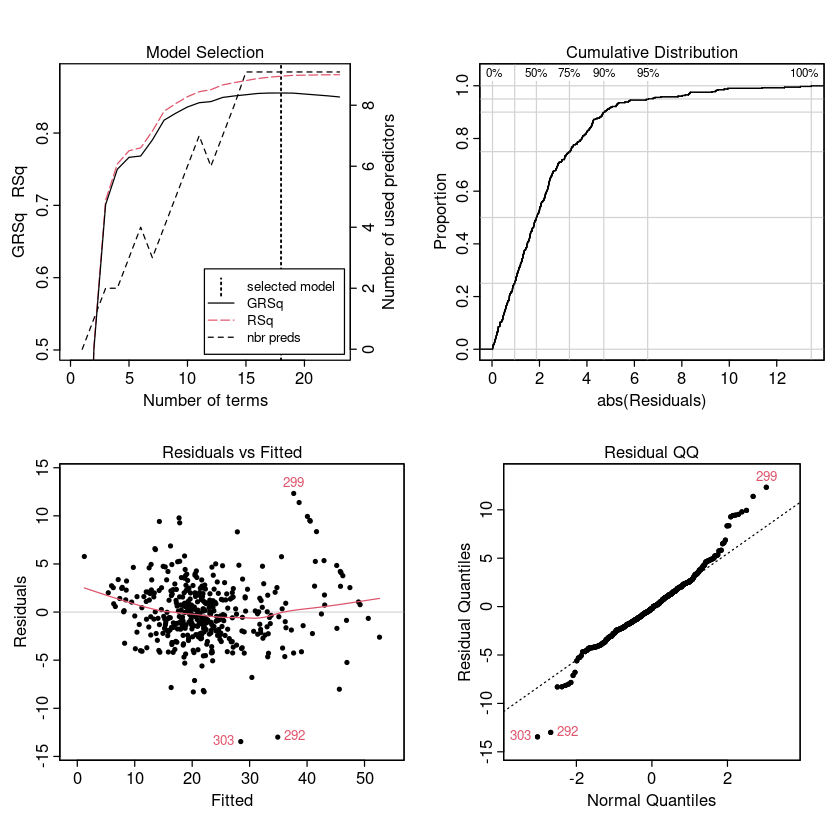

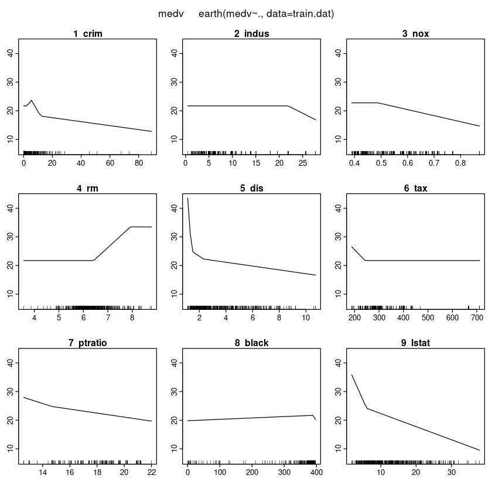

```r
#Fit a MARS model
mars_fit = earth(medv ~ ., data = train.dat)
summary(mars_fit)

#Model visulization : the effect of each variable
## Model diagnostics plot
plot(mars_fit, legend.pos = "bottomright", caption = "")


## plot each fitted functions holding other terms at their medians
plotmo(mars_fit, nrug = -1)

#For example: when nox is above 0.488,  the effect of nox on medv is "-21.136093" per unit change of nox,
#when holding other variables fixed.
```

Use "train" function to select the best hyper paramters

There are two crucial tuning hyper parameters: the maximum degree of interactions, and the number of terms in the final model. To determine the best combination of these hyperparameters, we need a grid search to minimize prediction error.

```r
# Model training using the caret package : train function
set.seed(295)

#Cross validation
cv.control =  trainControl(method = "cv",
                           number = 6)

#
# create a tuning grid
# degree:  the maximum degree of interactions ;  nprune: the number of terms in the final model
hyper_grid <- expand.grid(
  degree = 1:2,
  nprune = c(10, 13,  15, 17, 20)
)

#train to find the optimal tuning parameters
mars.fit = train(medv ~ ., data = train.dat,  method = "earth",
                   trControl = cv.control,
                   trace = FALSE,
                   tuneGrid = hyper_grid
               #    preProc = c("center", "scale"),
               #    maxit = 500
                )
```

```r
mars.fit

#The best tuning parameters
#the best tuning parameters
mars.fit$bestTune
```

```
Multivariate Adaptive Regression Spline

407 samples
 13 predictor

No pre-processing
Resampling: Cross-Validated (6 fold)
Summary of sample sizes: 339, 340, 338, 340, 339, 339, ...
Resampling results across tuning parameters:

  degree  nprune  RMSE      Rsquared   MAE
  1       10      4.029710  0.8138493  2.800669
  1       13      3.837058  0.8330866  2.682747
  1       15      3.822718  0.8334615  2.701992
  1       17      3.849014  0.8299345  2.756967
  1       20      3.843991  0.8301363  2.727077
  2       10      4.269243  0.7973679  2.871598
  2       13      4.345562  0.7972220  2.814051
  2       15      4.287846  0.8062151  2.743726
  2       17      4.100670  0.8190351  2.678294
  2       20      4.007732  0.8251963  2.608781

RMSE was used to select the optimal model using the smallest value.
The final values used for the model were nprune = 15 and degree = 1.
```

A data.frame: 1 × 2

|  | nprune <dbl> | degree <int> |
| --- | --- | --- |
| 3 | 15 | 1 |

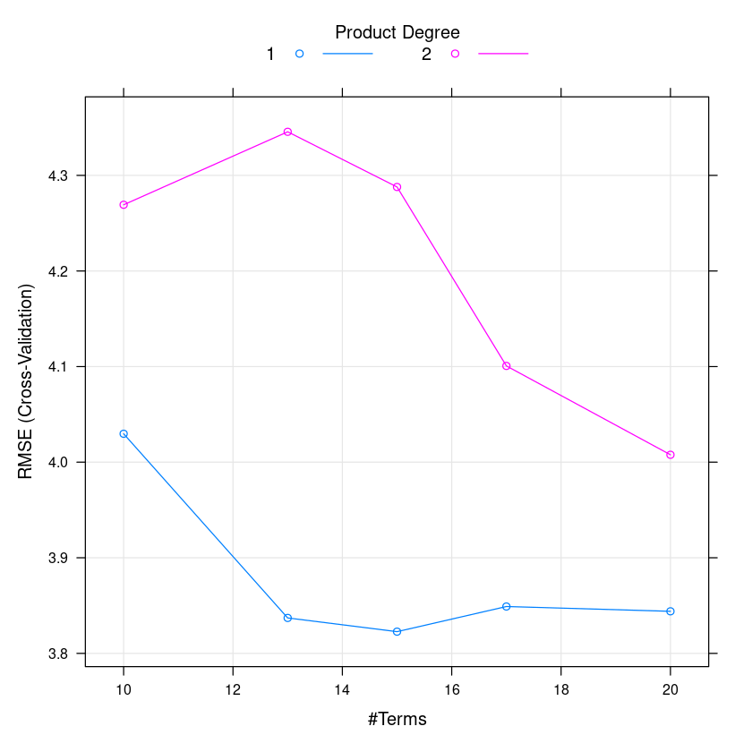

```r
plot(mars.fit)
```

3.68670633841888

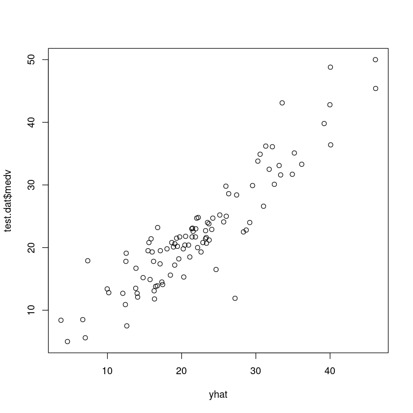

```r
#Make prediction on the testing data

yhat = predict(mars.fit, test.dat)

plot(yhat, test.dat$medv)

#RMSE on the testing data of the fitted model
caret::RMSE(test.dat$medv, yhat)
```

```
Call: earth(x=matrix[407,13], y=c(21.6,34.7,33...), keepxy=TRUE, degree=3,
            nprune=12)

                              coefficients
(Intercept)                       28.46807
h(6.417-rm)                       -5.99140
h(rm-6.417)                       11.56889
h(age-18.8)                       -0.07108
h(1.4165-dis)                    762.73161
h(dis-1.4165)                     -0.67579
h(1.4165-dis) * black             -1.86997
h(5.757-rm) * h(age-18.8)          0.12796
h(rm-6.417) * h(ptratio-18.4)     -7.17988
h(284-tax) * h(5.98-lstat)         0.04178
h(tax-284) * h(5.98-lstat)         0.02219
h(tax-330) * h(lstat-5.98)        -0.00166

Selected 12 of 26 terms, and 7 of 13 predictors (nprune=12)
Termination condition: Reached nk 27
Importance: rm, lstat, dis, tax, ptratio, black, age, crim-unused, ...
Number of terms at each degree of interaction: 1 5 6
GCV 10.13995    RSS 3569.218    GRSq 0.8818489    RSq 0.8973125
```

```
 plotmo grid:    crim zn indus chas   nox    rm  age    dis rad tax ptratio
               0.2498  0  9.69    0 0.538 6.208 77.8 3.1323   5 330    19.1
  black lstat
 391.83 11.34
```

```
Selected 12 of 26 terms, and 7 of 13 predictors (nprune=12)
Termination condition: Reached nk 27
Importance: rm, lstat, dis, tax, ptratio, black, age, crim-unused, ...
Number of terms at each degree of interaction: 1 5 6
GCV 10.13995    RSS 3569.218    GRSq 0.8818489    RSq 0.8973125
```

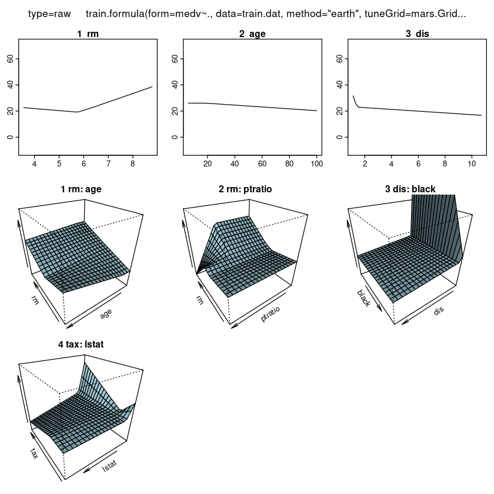

```r
# Train the MARS model , to find the optimal tuning parametesr
# Two hypparameters:   the maximum degree of interactions, and the number of terms in the final model

#To have the same results every time
set.seed(295)

ctrl = trainControl(method = "cv", number = 5)

#two hyper-parameters: the maximum degree of interactions, and the number of terms in the final model
mars.Grid = expand.grid(degree = 1:4, nprune = 2:100)

#Trains multiple MARS models with different parameter combinations.
#Evaluates each using cross-validation.
#Selects the best model based on performance metrics
mars.fit = train( medv ~ ., data = train.dat,
                  method = "earth",
                  tuneGrid = mars.Grid,
                  trControl = ctrl)
summary(mars.fit)

#partial plot
#Generates partial dependence plots (PDPs) for the fitted MARS model.Each plot shows how the predicted response changes as one predictor varies, keeping others fixed.Useful for visualizing nonlinear effects and interactions captured by the model.
plotmo(mars.fit)

mars.fit$finalModel
```

The grid specifies two key hyperparameters:

1. `degree`
- Defines the **maximum degree of interactions** allowed in the model.
- **`degree = 1`**: includes only **main effects** (no interaction terms).
- **`degree = 2`**: allows **two-way interactions**, and so on up to **`degree = 4`**.
2. `nprune`
- Specifies the **number of terms (basis functions)** to include in the **final pruned model**.
- MARS begins by constructing a large model and then **prunes it** to prevent overfitting.

#### Grid Range

The model is tuned over the following parameter ranges:

- `degree`: from **1 to 4**
- `nprune`: from **2 to 100**

Hence, the grid explores a total of
$$4 \times 99 = 396$$
possible combinations of hyperparameters.

The figure displays the **partial dependence plots (PDPs)** and **interaction surface plots** for the model predicting median house value (`medv`) from the Boston housing dataset. The **top row** shows the main effects of individual predictors, while the **bottom rows** illustrate how pairs of predictors interact. The first three 1D plots indicate that `medv` increases with the average number of rooms (`rm`), slightly decreases with the proportion of older homes (`age`), and drops sharply with greater distance from employment centers (`dis`). These nonlinear relationships suggest that more rooms and proximity to job centers increase housing values, while older housing areas reduce them. The 3D surface plots reveal several important interactions. The combination of **`rm` and `age`** shows that newer homes with more rooms have the highest predicted values. The **`rm` and `ptratio`** interaction indicates that houses with more rooms and lower pupil-teacher ratios (better schools) are more valuable. The **`dis` and `black`** interaction reflects how neighborhood composition modifies the effect of distance on housing values. Finally, the **`tax` and `lstat`** interaction shows that areas with higher tax rates and higher proportions of low-status residents have the lowest predicted house values. Overall, these plots demonstrate that the MARS model captures complex **nonlinear** and **interactive** relationships that linear models would miss.

```r
#The final model selected
mars.fit$finalModel

mars.fit$bestTune

coef(mars.fit$finalModel)
```

```
Selected 12 of 26 terms, and 7 of 13 predictors (nprune=12)
Termination condition: Reached nk 27
Importance: rm, lstat, dis, tax, ptratio, black, age, crim-unused, ...
Number of terms at each degree of interaction: 1 5 6
GCV 10.13995    RSS 3569.218    GRSq 0.8818489    RSq 0.8973125
```

A data.frame: 1 × 2

|  | nprune <int> | degree <int> |
| --- | --- | --- |
| 209 | 12 | 3 |

**(Intercept)**

28.4680683974249

**h(rm-6.417)**

11.5688920877369

**h(6.417-rm)**

-5.99139893795382

**h(rm-6.417) * h(ptratio-18.4)**

-7.17988162003179

**h(tax-284) * h(5.98-lstat)**

0.0221902280917752

**h(284-tax) * h(5.98-lstat)**

0.0417787338058719

**h(tax-330) * h(lstat-5.98)**

-0.00166156531119545

**h(dis-1.4165)**

-0.675794453274788

**h(1.4165-dis)**

762.731611460782

**h(1.4165-dis) * black**

-1.86997067311986

**h(age-18.8)**

-0.0710779358259277

**h(5.757-rm) * h(age-18.8)**

0.127958838291975

A data.frame: 1 × 8

| degree <int> | nprune <int> | RMSE <dbl> | Rsquared <dbl> | MAE <dbl> | RMSESD <dbl> | RsquaredSD <dbl> | MAESD <dbl> |
| --- | --- | --- | --- | --- | --- | --- | --- |
| 3 | 12 | 3.509828 | 0.8597695 | 2.505702 | 0.4548542 | 0.02810607 | 0.2093158 |

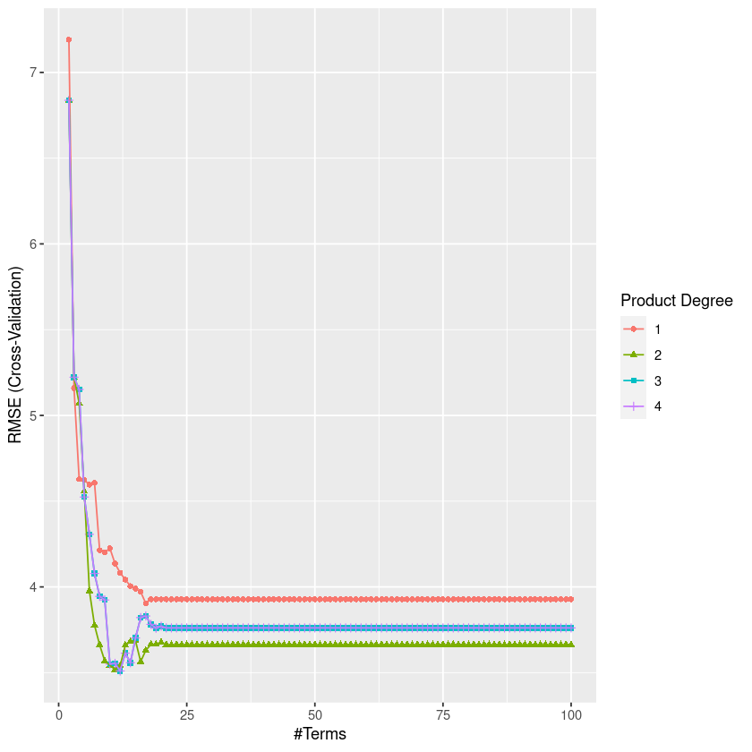

```r
#to extract the performance metrics corresponding to the best-tuned MARS model from the cross-validation results stored in mars.fit
mars.fit$results %>%
  filter(nprune == mars.fit$bestTune$nprune, degree == mars.fit$bestTune$degree)

#To provide a visual diagnostic of how the MARS model’s accuracy changes with varying model complexity, and to confirm that the selected hyperparameters
ggplot(mars.fit)
```